# Probability 1

Autumn 2025

## Combinations, permutations, and goats

## Objectives

## Probability

- Measurement of the likelihood of an event.
- Can be used to analyse historical data or to make future predictions
- Probability has many and varied applications.

## Probability

\[ \text{Probability of event }e = \dfrac{\text{number of occurances of event }e}{\text{total number of events}} \]

## Dice

- Probability of rolling a particular number of an \(n\)-sided fair die is \(1/n\).
- E.g., for a \(6\)-sided fair die, the probability of rolling a \(4\) (or any other number) is \(1/6\).
- Physical dice are platonic solids

  \(4\), \(6\), \(8\), \(12\) or \(20\) sides.
- Computer programs can model any number of sides of course, but there true randomness is a problem.

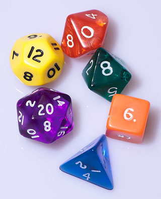

## Probability of dice rolls

- \(6\)-sided die:
  - \(6\) possible outcomes, each is equally likely.
  - Probability of rolling a given number is \(1\) in \(6\) (or \(1/6\))
- A \(20\)-sided die is \(1/20\), and so on.

## Two or more dice

- Now we consider all combinations of possible outcomes for each die.
- Sometimes we care about the individual rolls, either ordered or not.
- We are interested in the total score.

## Two dice: total score

Roll *two* fair \(6\)-sided dice.

- What is the total score?
- How many combinations result in a \(12\)?
- What about a \(2\)?
- What about a \(6\)?

## Let’s list the possibilities

| Score | How to roll it | Number of possibilities |
| --- | --- | --- |
| 2 | \(1\) and \(1\) | 1 |
| 3 | \(1\) and \(2\) | 1 |
| 4 | \(1\) and \(3\), \(2\) and \(2\) | 2 |
| 5 | \(1\) and \(4\), \(2\) and \(3\) | 2 |
| 6 | \(1\) and \(5\), \(2\) and \(4\), \(3\) and \(3\) | 3 |
| 7 | \(1\) and \(6\), \(2\) and \(5\), \(3\) and \(4\) | 3 |
| 8 | \(2\) and \(6\), \(3\) and \(5\), \(4\) and \(4\) | 3 |
| 9 | \(3\) and \(6\), \(4\) and \(5\) | 2 |
| 10 | \(4\) and \(6\), \(5\) and \(5\) | 2 |
| 11 | \(5\) and \(6\) | 1 |
| 12 | \(6\) and \(6\) | 1 |

## Waaaaaait!

- But aren’t there \(36\) different possible outcomes?
- \(6\) possibilities, \(2\) dice, \(6^2 = 36\).
- There are \(36\) *ordered* pairs of outcomes,

| Score | How to roll it | Number of possibilities |
| --- | --- | --- |
| 2 | \((1,1)\) | 1 |
| 3 | \((1,2),(2,1)\) | 2 |
| 4 | \((1,3),(3,1), (2,2)\) | 3 |
| 5 | \((1,4),(4,1), (2,3), (3,2)\) | 4 |
| 6 | \((1,5), (5,1), (2,4), (4,2), (3,3)\) | 5 |
| 7 | \((1,6), (6,1) (2,5), (5,2), (3,4, 4,3)\) | 6 |
| 8 | \((2,6),(6,2) (3,5),(5,3),(4,4)\) | 5 |
| 9 | \((3,6), (6,3), (4,5), (5,4)\) | 4 |
| 10 | \((4,6),(6,4), (5,5)\) | 3 |
| 11 | \((5,6),(6,5)\) | 2 |
| 12 | \((6,6)\) | 1 |

## Ordered possible combinations

- We could write them all out, but that’s boring.
- To get a score of \(3\) we roll
  - a \(1\) and a \(2\)
  - \((1,2)\) or \((2,1)\)
- To roll a \(7\), we could roll
  - \(1\) and \(6\): \((1,6)\) or \((6,1)\), or
  - \(2\) and \(5\): \((2,5)\) or \((5,2)\), or
  - \(3\) and \(4\): \((3,4)\) or \((4,3)\).
- So do we have *twice* the number of ordered pairs as unordered?

## No!

- To roll a \(6\), we could roll
  - \(1\) and \(5\): \((1,5)\) or \((5,1)\), or
  - \(2\) and \(4\): \((2,4)\) or \((4,2)\), or
  - \(3\) and \(3\): just \((3,3)\).
- For \(2\), \(4\), \(6\), \(8\), \(10\) and \(12\), we could roll

  two \(1\)’s, or two \(2\)’s, or two \(3\)’s, and so on.
- We have *six* possible rolls of the kind \((n, n)\).
- \(2 \cdot 21 = 42\) (from the previous table),
- \(42 - 6\) (subtract the duplicates \((n, n)\)),
- we get \(36 = 6 \cdot 6\).

## Ordered vs Unordered

### Unordered: combinations

- \(3\) possible ways to roll a \(6\)
- \(21\) total possible rolls.
- Probability of rolling a \(6\) is \(3/21=1/7\).
- This is equal to \(12/84\)

  \(\approx 0.14286 \approx 14\%\)

## Graph of the distributions

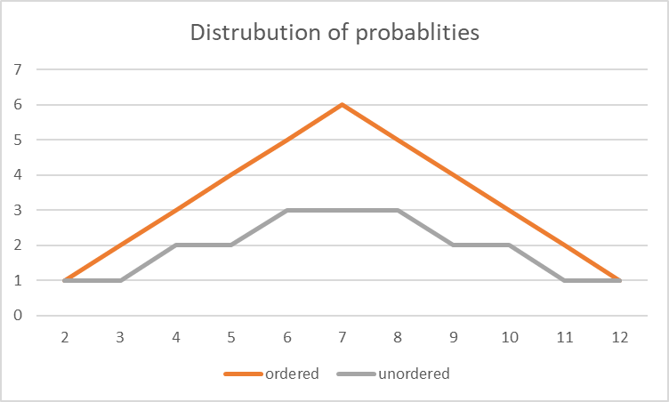

## When to use each one

You need to decide when to use ordered and unordered calculation.

Rule of thumb:

- **Simultaneous**: use unordered (combinations)

  “events happening at the same time”
- **Sequential**: use ordered (permutations)

  “one event takes place followed by another”